# Twitter LDA Topic Modeling

## 🧭 Overview & Setup

This tutorial walks you through on:

1. How to preprocess text for text analysis
2. How to perform a LDA topic modeling analysis
3. How to plot the top terms for each topic

### 📦 Install and load packages

Install the following packages if you do not have them in your R environment.

- `tidyverse` is a collection of R packages for data science
- `tidytext` is used to preprocess data for text mining
- `topicmodels` is used to perform Latent Dirichlet Allocation (LDA) topic modeling analysis
- `reshape2` is a dependency that may need to be installed manually
- `LDAvis` is used to interactively visualize topic modeling results using a web-based viewer

Note that the result of your analysis may differ based on the `tidytext` version. Specifically, the tokenizing logic from version `0.4.0` (released on December 20th, 2022) and above has been updated. `token = "tweets"` option has been deprecated and will throw an error. This notebook assumes that you’re using `tidytext` version `>=0.4.0`.

```r
# uncomment and run the lines below if you need to install these packages

# install.packages("tidyverse")
# install.packages("tidytext")
# install.packages("topicmodels")
# install.packages("reshape2")
# install.packages("LDAvis")
```

Load packages.

```r
library(tidyverse)
library(tidytext)
library(topicmodels)
library(reshape2)
library(LDAvis)
```

### 📃 Read CSV file

```r
df_tweets = read_csv('Coinbase-tweets.csv')
df_tweets %>% head()
```

| id | username | text |
| --- | --- | --- |
| 1.603438e+18 | elaineyyly | @coinbase Please can someone come on @RealVision and explain this to me |
| 1.603438e+18 | Blockworks_ | Coinbase’s stock price dipped below $38 Thursday after starting the year at roughly $250.\n\nLatest from @strack_ben \n\nhttps://t.co/AjPRy7ObJu |
| 1.603437e+18 | CoinbaseSupport | @heyitskhi Thanks for your reply. Alternatively, please follow the steps here: https://t.co/RYfN1d97mu, and if you are still having an issue, please follow our device troubleshooting guide here: https… |
| 1.603434e+18 | CoinbaseSupport | @heyitskhi Hey @heyitskhi, thanks for reaching out about Asset Recovery through Coinbase! We're excited to offer it, and want you to be able to use it as soon as possible. Have you checked https://t.c… |
| 1.603432e+18 | CryptoWendyO | DID COINBASE ACTUALLY PROVIDE GOOD CUSTOMER SERVICE TO THEIR CUSTOMERS?! https://t.co/lEmAvLlnhI |
| 1.603431e+18 | pkafka | Thought Trump was selling ersatz NFTs bc why not just skip the blockchain tech and go straight for the grift. Bigger TAM. But!\n\n"Owner must ensure that she/he/it obtains and maintains a functioning … |

Print out the number of rows.

```r
nrow(df_tweets)
```

```
## [1] 654
```

## 🔨 Text Pre-processing

### 📌 Add row number to df_tweets

Create a new column named `row_num` with unique values in each row. This allows us to group by each tweet after we tokenize the tweet text.

```r
df_tweets$row_num <- seq_len(nrow(df_tweets))
df_tweets %>% head() %>% select(-text)
```

| id | username | row_num |
| --- | --- | --- |
| 1.603438e+18 | elaineyyly | 1 |
| 1.603438e+18 | Blockworks_ | 2 |
| 1.603437e+18 | CoinbaseSupport | 3 |
| 1.603434e+18 | CoinbaseSupport | 4 |
| 1.603432e+18 | CryptoWendyO | 5 |
| 1.603431e+18 | pkafka | 6 |

### 🔗 Remove URLs

Many tweets contain URL strings in the form of “https://t.co/somestring”. Remove these URL strings using a regular expression

```r
df_tweets$text <- df_tweets$text %>%
  str_remove_all("https://t.co/\\w+")

df_tweets %>%
  select(text) %>%
  head()
```

| text |
| --- |
| @coinbase Please can someone come on @RealVision and explain this to me |
| Coinbase’s stock price dipped below $38 Thursday after starting the year at roughly $250.\n\nLatest from @strack_ben \n\n |
| @heyitskhi Thanks for your reply. Alternatively, please follow the steps here: , and if you are still having an issue, please follow our device troubleshooting guide here: . Many thanks. \n^JH |
| @heyitskhi Hey @heyitskhi, thanks for reaching out about Asset Recovery through Coinbase! We're excited to offer it, and want you to be able to use it as soon as possible. Have you checked ?\n^KB |
| DID COINBASE ACTUALLY PROVIDE GOOD CUSTOMER SERVICE TO THEIR CUSTOMERS?! |
| Thought Trump was selling ersatz NFTs bc why not just skip the blockchain tech and go straight for the grift. Bigger TAM. But!\n\n"Owner must ensure that she/he/it obtains and maintains a functioning … |

### ⚔️ Tokenize and normalize

Tokenize tweet texts and normalize the tokens.

```r
# tokenize using unnest_tokens()
# this also normalizes the tokens (lowercase, remove punctuations except Twitter-specific characters for mentions, tickers, and URLs)
# token = "tweets" preserves usernames and hashtags
df_tokens <- df_tweets %>%
  tidytext::unnest_tokens(input = text, output = word)

df_tokens %>% head(n = 10)
```

| id | username | row_num | word |
| --- | --- | --- | --- |
| 1.603438e+18 | elaineyyly | 1 | coinbase |
| 1.603438e+18 | elaineyyly | 1 | please |
| 1.603438e+18 | elaineyyly | 1 | can |
| 1.603438e+18 | elaineyyly | 1 | someone |
| 1.603438e+18 | elaineyyly | 1 | come |
| 1.603438e+18 | elaineyyly | 1 | on |
| 1.603438e+18 | elaineyyly | 1 | realvision |
| 1.603438e+18 | elaineyyly | 1 | and |
| 1.603438e+18 | elaineyyly | 1 | explain |
| 1.603438e+18 | elaineyyly | 1 | this |

### 🪓 Remove stop words

Stop words are words that are commonly used and likely unimportant. Examples include “is”, “by”, “the”, “a”, etc.

```r
# remove stop words using anti_join
# and remove tokens with only 1 or 2 characters
df_tokens <- df_tokens %>%
  anti_join(tidytext::stop_words, by = "word") %>%
  filter(nchar(word) >= 3)

df_tokens %>% head(n = 10)
```

| id | username | row_num | word |
| --- | --- | --- | --- |
| 1.603438e+18 | elaineyyly | 1 | coinbase |
| 1.603438e+18 | elaineyyly | 1 | realvision |
| 1.603438e+18 | elaineyyly | 1 | explain |
| 1.603438e+18 | Blockworks_ | 2 | coinbase’s |
| 1.603438e+18 | Blockworks_ | 2 | stock |
| 1.603438e+18 | Blockworks_ | 2 | price |
| 1.603438e+18 | Blockworks_ | 2 | dipped |
| 1.603438e+18 | Blockworks_ | 2 | thursday |
| 1.603438e+18 | Blockworks_ | 2 | starting |
| 1.603438e+18 | Blockworks_ | 2 | roughly |

### 🔮 Most frequent tokens

```r
df_tokens %>% count(word) %>% arrange(desc(n))
```

| word | n |
| --- | --- |
| coinbase | 501 |
| crypto | 119 |
| issue | 69 |
| usdc | 54 |
| wallet | 51 |
| status | 47 |
| binance | 45 |
| page | 45 |
| exchange | 44 |
| hear | 44 |

[output cut: 2870 more lines]

## 🔨 LDA Analysis

### 📐 Create a Document-term Matrix

- Each row in our Document-term Matrix represents a tweet.
- Each column represents a word (e.g., “bankruptcy”).
- Each cell contains the frequency of the word.

```r
dtm <- df_tokens %>%
  count(row_num, word) %>%
  cast_dtm(document = row_num, term = word, value = n)

dtm
```

```
## <<DocumentTermMatrix (documents: 654, terms: 2880)>>
## Non-/sparse entries: 7789/1875731
## Sparsity           : 100%
## Maximal term length: 20
## Weighting          : term frequency (tf)
```

### 🧪 Run LDA with 3 topics (`k = 3`)

```r
tweets_lda <- topicmodels::LDA(dtm, k = 3, control = list(seed = 12))
tweets_lda
```

```
## A LDA_VEM topic model with 3 topics.
```

Print out per-topic-per-word probabilities.

**beta** values are the probabilities of words in each topic.

```r
tweet_topics <- tidytext::tidy(tweets_lda, matrix = "beta")

top_terms <- tweet_topics %>%
  group_by(topic) %>%
  slice_max(beta, n = 20) %>%
  ungroup() %>%
  arrange(topic, -beta)

top_terms
```

| topic | term | beta |
| --- | --- | --- |
| 1 | coinbase | 0.085822048 |
| 1 | crypto | 0.024286279 |
| 1 | usdc | 0.016456078 |
| 1 | usdt | 0.012529551 |
| 1 | ftx | 0.010031068 |
| 1 | exchange | 0.009823154 |
| 1 | users | 0.008693417 |
| 1 | stablecoin | 0.008457447 |
| 1 | court | 0.007517730 |
| 1 | arbitration | 0.007517291 |

[output cut: 50 more lines]

### 📊 Plot the top 20 terms

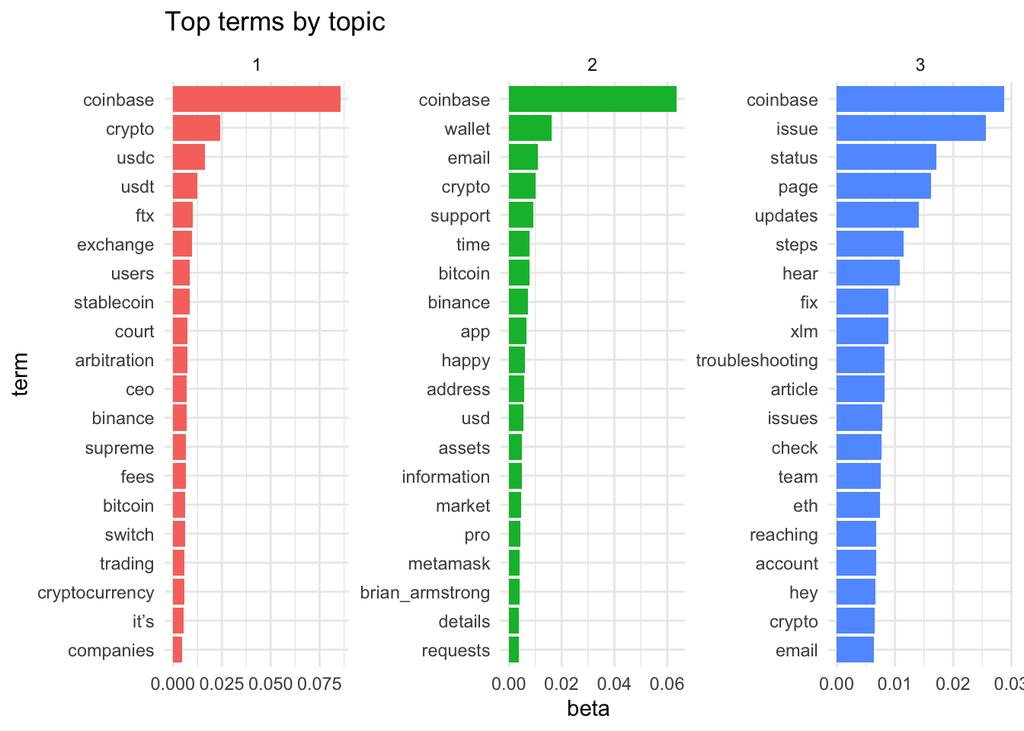

```r
top_terms %>%
  mutate(term = reorder_within(term, beta, topic)) %>%
  ggplot(aes(beta, term, fill = factor(topic)))+
  geom_col(show.legend = FALSE) +
  theme_minimal() +
  ggtitle("Top terms by topic") +
  facet_wrap(~topic, scales = "free") +
  scale_y_reordered()
```